# Introduction to BASiCS

Catalina Vallejos and Nils Eling

cnvallej@uc.cl  
eling@ebi.ac.uk

28 November 2018

#### Package

BASiCS 1.5.0

# 1 Introduction

Single-cell mRNA sequencing can uncover novel cell-to-cell heterogeneity in gene expression levels within seemingly homogeneous populations of cells. However, these experiments are prone to high levels of technical noise, creating new challenges for identifying genes that show genuine heterogeneous expression within the group of cells under study.

[figure not shown]

BASiCS (**B**ayesian **A**nalysis of **Si**ngle-**C**ell **S**equencing data) is an integrated Bayesian hierarchical model that propagates statistical uncertainty by simultaneously performing data normalisation (global scaling), technical noise quantification and two types of **supervised** downstream analyses:

1. **For a single group of cells** (Vallejos, Marioni, and Richardson 2015): BASiCS provides a criterion to identify highly (and lowly) variable genes within the group.
2. **For two (or more) groups of cells**: BASiCS allows the identification of changes in gene expression between the groups. As in traditional differential expression tools, BASiCS can uncover changes in mean expression between the groups. Besides this, BASiCS can also uncover changes in gene expression variability in terms of:
1. **Over-dispersion** (Vallejos, Richardson, and Marioni 2016) — a measure for the excess of cell-to-cell variability that is observed with respect to Poisson sampling, after accounting for technical noise. This feature has led, for example, to novel insights in the context of immune cells across aging (Martinez-Jimenez et al. 2017). However, due to the strong mean/over-dispersion confounding that is typically observed for scRNA-seq datasets, the assessment of changes in over-dispersion is restricted to genes for which mean expression does not change between the groups.
2. **Residual over-dispersion** (Eling et al. 2018) — a residual measure of variability given by departures with respect to a global mean/over-dispersion trend. Positive residual over-dispersion indicates that a gene exhibits more variation than expected relative to genes with similar expression levels; negative residual over-dispersion suggests less variation than expected. To use this feature, please set `Regression = TRUE` as a function parameter in `BASiCS_MCMC`.

In all cases, a probabilistic output is provided and a decision rule is calibrated using the expected false discovery rate (EFDR) (Newton et al. 2004).

A brief description for the statistical model implemented in BASiCS is provided in Section 6 of this document. The original implementation of BASiCS (Vallejos, Marioni, and Richardson 2015) requires the use of **spike-in** molecules — that are artificially introduced to each cell’s lysate — to perform these analyses. More recently, Eling et al. (2018) extendeded BASiCS to also address datasets for which spikes-ins are not available (see Section 4). To use this feature, please set `WithSpikes = FALSE` as a function parameter in `BASiCS_MCMC`.

**Important**: BASiCS has been designed in the context of supervised experiments where the groups of cells (e.g. experimental conditions, cell types) under study are known a priori (e.g. case-control studies). Therefore, we DO NOT advise the use of BASiCS in unsupervised settings where the aim is to uncover sub-populations of cells through clustering.

# 2 Quick start

Parameter estimation is performed using the `BASiCS_MCMC` function. Downstream analyses implemented in BASiCS rely on appropriate post-processing of the output returned by `BASiCS_MCMC`. Essential parameters for running `BASiCS_MCMC` are:

- `Data`: a `SingleCellExperiment` object created as in Section 3.1
- `N`: total number of iterations
- `Thin`: length of the thining period (i.e. only every `Thin` iterations will be stored in the output of the `BASiCS_MCMC`)
- `Burn`: length of burn-in period (i.e. the initial `Burn` iterations that will be discarded from the output of the `BASiCS_MCMC`)
- `Regression`: if this parameter is set equal to `TRUE`, the regression BASiCS model will be used (Eling et al. 2018). The latter infers a global regression trend between mean expression and over-dispersion parameters. This trend is subsequently used to derive a *residual over-dispersion* measure that is defined as departures with respect to this trend. **This is now the recommended default setting for BASiCS***.

If the optional parameter `PrintProgress` is set to `TRUE`, the R console will display the progress of the MCMC algorithm. For other optional parameters refer to `help(BASiCS_MCMC)`.

Here, we illustrate the usage of `BASiCS_MCMC` using a built-in synthetic dataset.

```r
Data <- makeExampleBASiCS_Data()
Chain <- BASiCS_MCMC(Data = Data, N = 1000, Thin = 10, Burn = 500,
                     PrintProgress = FALSE, Regression = TRUE)
```

```
## -----------------------------------------------------
## MCMC sampler has been started: 1000 iterations to go.
## -----------------------------------------------------
## -----------------------------------------------------
## End of Burn-in period.
## -----------------------------------------------------
##
## -----------------------------------------------------
## -----------------------------------------------------
## All 1000 MCMC iterations have been completed.
## -----------------------------------------------------
## -----------------------------------------------------
##
## -----------------------------------------------------
## Please see below a summary of the overall acceptance rates.
## -----------------------------------------------------
##
## Minimum acceptance rate among mu[i]'s: 0.446
## Average acceptance rate among mu[i]'s: 0.6158
## Maximum acceptance rate among mu[i]'s: 0.74
##
##
## Minimum acceptance rate among delta[i]'s: 0.418
## Average acceptance rate among delta[i]'s: 0.51276
## Maximum acceptance rate among delta[i]'s: 0.606
##
##
## Acceptance rate for phi (joint): 0.864
##
##
## Minimum acceptance rate among nu[j]'s: 0.434
## Average acceptance rate among nu[j]'s: 0.532533
## Maximum acceptance rate among nu[j]'s: 0.718
##
##
## Minimum acceptance rate among theta[k]'s: 0.724
## Average acceptance rate among theta[k]'s: 0.724
## Maximum acceptance rate among theta[k]'s: 0.724
##
## -----------------------------------------------------
##
```

The `Data` and `Chain` (a `BASiCS_Chain` object) objects created by the code above can be use for subsequent downstream analyses. See Section 3.2 for highly/lowly variable gene detection (single group of cells, see also functions `BASiCS_DetectHVG` and `BASiCS_DetectLVG`) and Section 3.3 for differential expression analyses (two groups of cells, see also function `BASiCS_TestDE`).

**Important remarks:**

- Please ensure the acceptance rates displayed in the console output of `BASiCS_MCMC` are around 0.44. If they are too far from this value, you should increase `N` and `Burn`.
- It is **essential** to assess the convergence of the MCMC algorithm **before** performing downstream analyses. For guidance regarding this step, refer to the ‘Convergence assessment’ section of this vignette

Typically, setting `N=20000`, `Thin=20` and `Burn=10000` leads to stable results.

# 3 Complete workflow

## 3.1 The input dataset

The input dataset for BASiCS must be stored as an `SingleCellExperiment` object (see *SingleCellExperiment* package).

The generation of the input `SingleCellExperiment` object requires a matrix of raw counts `Counts` (columns: cells, rows: genes) after quality control (e.g. removing low quality cells) and filtering of lowly expressed genes. If spike-in molecules are contained in `Counts`, a logical vector `Tech` is required to indicate which rows contain technical spike-in molecules and a `data.frame` object `SpikeInfo` containing the names of the spike-in molecules in the first column and the absolute number of molecules per well in the second column. More details are provided in section 3.1. If spike-ins are not available, a vector `BatchInfo` containing batch information is required.

### 3.1.1 With spike-in genes

The `newBASiCS_Data` function can be used to create the input data object based on the following information:

- `Counts`: a matrix of raw expression counts with dimensions $q$ times $n$. Within this matrix, $q_0$ rows must correspond to biological genes and $q-q_0$ rows must correspond to technical spike-in genes. Gene names must be stored as `rownames(Counts)`.
- `Tech`: a logical vector (`TRUE`/`FALSE`) with $q$ elements. If `Tech[i] = FALSE` the gene `i` is biological; otherwise the gene is spike-in. This vector must be specified in the same order of genes as in the `Counts` matrix.
- `SpikeInfo` (optional): a `data.frame` with $q-q_0$ rows. First column must contain the names associated to the spike-in genes (as in `rownames(Counts)`). Second column must contain the input number of molecules for the spike-in genes (amount per cell). If a value for this parameter is not provided when calling `newBASiCS_Data`, `SpikeInfo` is set as `NULL` as a default value. In those cases, the `BatchInfo` argument has to be provided to allow using the no-spikes implementation of BASiCS.
- `BatchInfo` (optional): vector of length $n$ to indicate batch structure (whenever cells have been processed using multiple batches). If a value for this parameter is not provided when calling `newBASiCS_Data`, BASiCS will assume the data contains a single batch of samples.

For example, the following code generates a synthetic dataset with 50 genes (40 biological and 10 spike-in) and 40 cells.

```r
set.seed(1)
Counts <- matrix(rpois(50*40, 2), ncol = 40)
rownames(Counts) <- c(paste0("Gene", 1:40), paste0("Spike", 1:10))
Tech <- c(rep(FALSE,40),rep(TRUE,10))
set.seed(2)
SpikeInput <- rgamma(10,1,1)
SpikeInfo <- data.frame("SpikeID" = paste0("Spike", 1:10),
                        "SpikeInput" = SpikeInput)

# No batch structure
DataExample <- newBASiCS_Data(Counts, Tech, SpikeInfo)

# With batch structure
DataExample <- newBASiCS_Data(Counts, Tech, SpikeInfo,
                              BatchInfo = rep(c(1,2), each = 20))
```

To convert an existing `SingleCellExperiment` object (`Data`) into one that can be used within BASiCS, meta-information must be stored in the object.

- `isSpike(Data, "ERCC") <- Tech`: the logical vector indicating biological/technical genes (see above) must be stored in the `int_metadata` slot via the `isSpike` function.
- `metadata(Data)`: the `SpikeInfo` object is stored in the `metadata` slot of the `SingleCellExperiment` object: `metadata(Data) <- list(SpikeInput = SpikeInfo[,2], BatchInfo = BatchInfo)`.
- `colData(Data)$BatchInfo`: the `BatchInfo` object is stored in the `colData` slot of the `SingleCellExperiment` object.

Once the additional information is included, the object can be used within BASiCS.

### 3.1.2 Without spike-in genes

To run BASiCS without incorporating reads from technical spike-in genes, and existing `SingleCellExperiment` object can be used. The only modification to the existing object is to assign the `colData(Data)$BatchInfo` slot.

```r
set.seed(1)
CountsNoSpikes <- matrix(rpois(50*40, 2), ncol = 40)
rownames(CountsNoSpikes) <- paste0("Gene", 1:50)

# With batch structure
DataExampleNoSpikes <- SingleCellExperiment(assays = list(counts = CountsNoSpikes),
                      colData = data.frame(BatchInfo = rep(c(1,2), each = 20)))
```

Note: BASiCS assumes that a pre-processing quality control step has been applied to remove cells with poor quality data and/or lowly expressed genes that were undetected through sequencing. When analysing multiple groups of cells, the gene filtering step must be jointly applied across all groups to ensure the same genes are retained.

The function `BASiCS_Filter` can be used to perform this task. For examples, refer to `help(BASiCS_Filter)`. Moreover, the *scater* package provides enhanced functionality for the pre-processing of scRNA-seq datasets.

## 3.2 Analysis for a single group of cells

We illustrate this analysis using a small extract from the MCMC chain obtained in (Vallejos, Richardson, and Marioni 2016) when analysing the single cell samples provided in (Grün, Kester, and Oudenaarden 2014). This is included within `BASiCS` as the `ChainSC` dataset.

```r
data(ChainSC)
```

For each gene, these functions return posterior probabilities as a measure of HVG/LVG evidence. A cut-off value for these posterior probabilities is set by controlling the EFDR (as a default option, EFDR is set as 0.10).

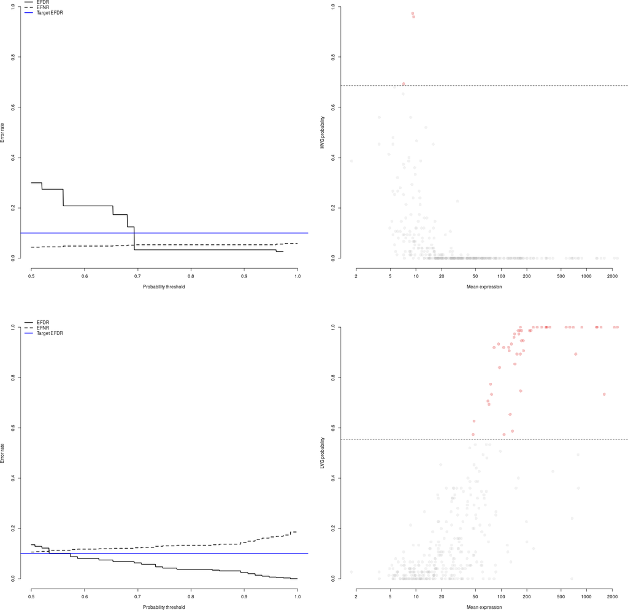

```r
par(mfrow = c(2,2))
HVG <- BASiCS_DetectHVG(ChainSC, VarThreshold = 0.6, Plot = TRUE)
LVG <- BASiCS_DetectLVG(ChainSC, VarThreshold = 0.2, Plot = TRUE)
```

To access the results of these tests, please use.

```r
head(HVG$Table)
```

```
##     GeneIndex GeneName       Mu    Delta     Sigma      Prob   HVG
## 286       286   Rhox13 9.138169 2.417712 0.7706052 0.9733333  TRUE
## 250       250   Phlda2 9.372955 2.171966 0.7462231 0.9600000  TRUE
## 21         21    Amacr 7.164534 1.598386 0.6652893 0.6933333  TRUE
## 320       320    Smoc1 5.623408 1.805558 0.6700561 0.6800000 FALSE
## 122       122   Engase 7.082273 1.579305 0.6445464 0.6533333 FALSE
## 66         66   Cep170 3.712116 1.580848 0.6261821 0.5600000 FALSE
```

```r
head(LVG$Table)
```

```
##     GeneIndex GeneName        Mu      Delta      Sigma Prob  LVG
## 20         20    Ahsa1  167.4669 0.06774259 0.09381064    1 TRUE
## 37         37   Atp5g2  344.9518 0.06381609 0.09037440    1 TRUE
## 55         55     Btf3  263.2987 0.04880375 0.06861493    1 TRUE
## 69         69   Chchd2  576.1569 0.03078477 0.04703723    1 TRUE
## 141       141    Fkbp4  334.4190 0.07084192 0.09782010    1 TRUE
## 147       147     Ftl1 2296.2110 0.04504962 0.06656222    1 TRUE
```

**Note**: this decision rule implemented in this function has changed with respect to the original release of BASiCS (where `EviThreshold` was defined such that EFDR = EFNR). However, the new choice is more stable (sometimes, it was not posible to find a threshold such that EFDR = EFNR).

## 3.3 Analysis for two groups of cells

To illustrate the use of the differential mean expression and differential over-dispersion tests between two cell populations, we use extracts from the MCMC chains obtained in (Vallejos, Richardson, and Marioni 2016) when analysing the (Grün, Kester, and Oudenaarden 2014) dataset (single cells vs pool-and-split samples). These were obtained by independently running the `BASiCS_MCMC` function for each group of cells.

```r
data(ChainSC)
data(ChainRNA)
```

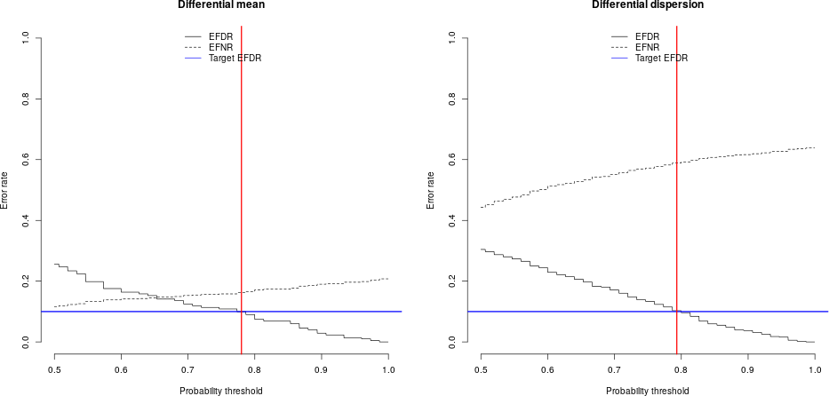

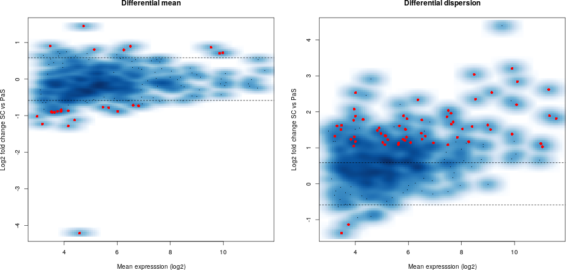

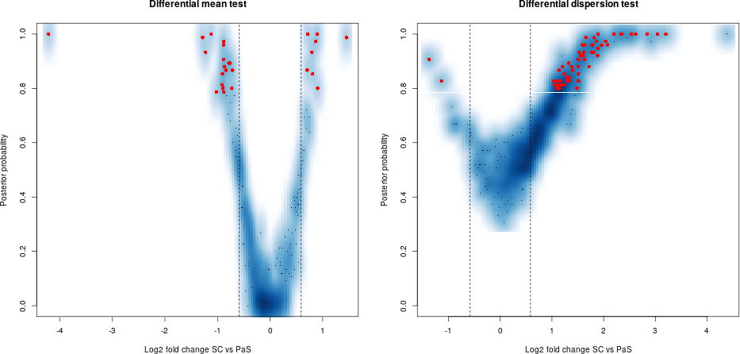

```r
Test <- BASiCS_TestDE(Chain1 = ChainSC, Chain2 = ChainRNA,
                      GroupLabel1 = "SC", GroupLabel2 = "PaS",
                      EpsilonM = log2(1.5), EpsilonD = log2(1.5),
                      EFDR_M = 0.10, EFDR_D = 0.10,
                      Offset = TRUE, PlotOffset = FALSE, Plot = TRUE)
```

In `BASiCS_TestDE`, `EpsilonM` sets the log2 fold change (log2FC) in expression ($\mu$) and `EpsilonD` the log2FC in over-dispersion ($\delta$). As a default option: `EpsilonM = EpsilonD = log2(1.5)` (i.e. the test is set to detect absolute increases of 50% or above). To adjust for differences in overall mRNA content, an internal offset correction is performed when `OffSet=TRUE`. This is the recommended default setting.

The resulting output list can be displayed using

```r
head(Test$TableMean)
```

```
##        GeneName MeanOverall   Mean1   Mean2 MeanFC MeanLog2FC ProbDiffMean
## 1 1700094D03Rik      58.539  54.352  62.726  0.854     -0.228        0.000
## 2 1700097N02Rik      37.421  36.919  37.922  0.946     -0.081        0.013
## 3 1810026B05Rik      14.738  10.459  19.018  0.558     -0.842        0.867
## 4 2310008H04Rik      18.844  15.267  22.422  0.672     -0.573        0.493
## 5 2410137M14Rik      19.050  16.674  21.426  0.768     -0.380        0.280
## 6 4930402H24Rik     962.255 967.739 956.771  1.004      0.006        0.000
##   ResultDiffMean
## 1         NoDiff
## 2         NoDiff
## 3           PaS+
## 4         NoDiff
## 5         NoDiff
## 6         NoDiff
```

```r
head(Test$TableDisp)
```

```
##        GeneName MeanOverall DispOverall Disp1 Disp2 DispFC DispLog2FC
## 1 1700094D03Rik      58.539       0.225 0.321 0.128  2.307      1.206
## 2 1700097N02Rik      37.421       0.338 0.476 0.200  2.342      1.228
## 3 1810026B05Rik      14.738       0.359 0.434 0.284  1.378      0.463
## 4 2310008H04Rik      18.844       0.392 0.441 0.343  1.204      0.268
## 5 2410137M14Rik      19.050       0.396 0.491 0.302  1.663      0.734
## 6 4930402H24Rik     962.255       0.103 0.186 0.020  9.209      3.203
##   ProbDiffDisp      ResultDiffDisp
## 1        0.880                 SC+
## 2        0.813                 SC+
## 3        0.520 ExcludedFromTesting
## 4        0.453              NoDiff
## 5        0.640              NoDiff
## 6        1.000                 SC+
```

Due to the confounding between mean and over-dispersion that is typically observed in scRNA-seq datasets, the non-regression BASiCS model (run using `Regression = FALSE` as a function parameter in `BASiCS_MCMC`) can only be used to assess changes in over-dispersion for those genes in which the mean expression does not change between the groups. In this case, we recommend users to use `EpsilonM = 0` as a conservative option to avoid changes in over-dispersion to be confounded by mean expression (the genes for which mean expression changes are marked as `ExcludedFromTesting` in the `Test$TableDisp$ResultDiffDisp` slot).

```r
Test <- BASiCS_TestDE(Chain1 = ChainSC, Chain2 = ChainRNA,
                      GroupLabel1 = "SC", GroupLabel2 = "PaS",
                      EpsilonM = 0, EpsilonD = log2(1.5),
                      EFDR_M = 0.10, EFDR_D = 0.10,
                      Offset = TRUE, PlotOffset = FALSE, Plot = FALSE)
```

**Note**: If the regression BASiCS model has been used (`Regression = TRUE` as a function parameter in `BASiCS_MCMC`), `BASiCS_TestDE` will also report changes in residual over-dispersion (not confounded by mean expression) between the groups (see Section 4 in this vignette).

# 4 Alternative implementation modes

Beyond its original implementation, BASiCS has been extended to address experimental designs in which spike-in molecules are not available as well as to address the confounding that is typically observed between mean and over-dispersion for scRNA-seq datasets (Eling et al. 2018). Alternative implementation modes are summarised below:

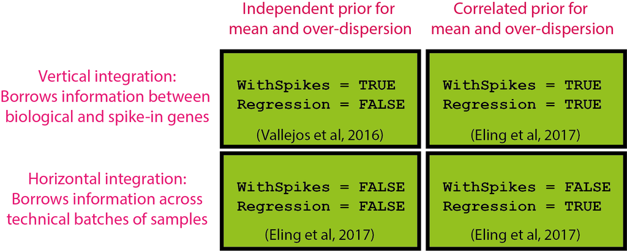

As a default, the `BASiCS_MCMC` function uses `WithSpikes = TRUE`.

## 4.1 If `WithSpikes = FALSE`

When technical spike-in genes are not available, BASiCS uses a horizontal integration strategy which borrows information across multiple technical replicates (Eling et al. 2018). Therefore, `BASiCS_MCMC` will fail to run if a single batch of samples is provided. **Note:** batch information must be provided via the `BatchInfo` argument when using the `newBASiCS_Data` function or `BatchInfo` must be stored as a slot in `colData(Data)` when using an existing `SingleCellExperiment` object.

```r
DataNoSpikes <- newBASiCS_Data(Counts, Tech, SpikeInfo = NULL,
                              BatchInfo = rep(c(1,2), each = 20))

# Alternatively
DataNoSpikes <- SingleCellExperiment(assays = list(counts = Counts),
                      colData = data.frame(BatchInfo = rep(c(1,2), each = 20)))

ChainNoSpikes <- BASiCS_MCMC(Data = DataNoSpikes, N = 1000,
                             Thin = 10, Burn = 500,
                             WithSpikes = FALSE,  Regression = TRUE,
                             PrintProgress = FALSE)
```

```
## -----------------------------------------------------
## MCMC sampler has been started: 1000 iterations to go.
## -----------------------------------------------------
## -----------------------------------------------------
## End of Burn-in period.
## -----------------------------------------------------
##
## -----------------------------------------------------
## -----------------------------------------------------
## All 1000 MCMC iterations have been completed.
## -----------------------------------------------------
## -----------------------------------------------------
##
## -----------------------------------------------------
## Please see below a summary of the overall acceptance rates.
## -----------------------------------------------------
##
## Minimum acceptance rate among mu[i]'s: 0.338
## Average acceptance rate among mu[i]'s: 0.451
## Maximum acceptance rate among mu[i]'s: 0.566
##
##
## Minimum acceptance rate among delta[i]'s: 0.736
## Average acceptance rate among delta[i]'s: 0.78204
## Maximum acceptance rate among delta[i]'s: 0.834
##
##
## Minimum acceptance rate among nu[jk]'s: 0.92
## Average acceptance rate among nu[jk]'s: 0.96525
## Maximum acceptance rate among nu[jk]'s: 0.99
##
##
## Minimum acceptance rate among theta[k]'s: 0.79
## Average acceptance rate among theta[k]'s: 0.792
## Maximum acceptance rate among theta[k]'s: 0.794
##
##
## -----------------------------------------------------
##
```

## 4.2 If `Regression = TRUE`

The BASiCS model uses a joint informative prior formulation to account for the relationship between mean and over-dispersion gene-specific parameters. The latter is used to infer a global regression trend between these parameters and, subsequently, to derive a *residual over-dispersion* measure that is defined as departures with respect to this trend.

```r
DataRegression <- newBASiCS_Data(Counts, Tech, SpikeInfo,
                              BatchInfo = rep(c(1,2), each = 20))
ChainRegression <- BASiCS_MCMC(Data = DataRegression, N = 1000,
                               Thin = 10, Burn = 500,
                               Regression = TRUE,
                               PrintProgress = FALSE)
```

```
## -----------------------------------------------------
## MCMC sampler has been started: 1000 iterations to go.
## -----------------------------------------------------
## -----------------------------------------------------
## End of Burn-in period.
## -----------------------------------------------------
##
## -----------------------------------------------------
## -----------------------------------------------------
## All 1000 MCMC iterations have been completed.
## -----------------------------------------------------
## -----------------------------------------------------
##
## -----------------------------------------------------
## Please see below a summary of the overall acceptance rates.
## -----------------------------------------------------
##
## Minimum acceptance rate among mu[i]'s: 0.324
## Average acceptance rate among mu[i]'s: 0.45165
## Maximum acceptance rate among mu[i]'s: 0.546
##
##
## Minimum acceptance rate among delta[i]'s: 0.738
## Average acceptance rate among delta[i]'s: 0.77755
## Maximum acceptance rate among delta[i]'s: 0.822
##
##
## Acceptance rate for phi (joint): 0.86
##
##
## Minimum acceptance rate among nu[j]'s: 0.804
## Average acceptance rate among nu[j]'s: 0.85035
## Maximum acceptance rate among nu[j]'s: 0.97
##
##
## Minimum acceptance rate among theta[k]'s: 0.718
## Average acceptance rate among theta[k]'s: 0.736
## Maximum acceptance rate among theta[k]'s: 0.754
##
## -----------------------------------------------------
##
```

This implementation provides additional functionality when performing downstream analyses. These are illustrated below using a small extract from the MCMC chain obtained when analysing the dataset provided in (Grün, Kester, and Oudenaarden 2014) (single cell versus pool-and-split samples). These are included within `BASiCS` as the `ChainSCReg` and `ChainRNAReg` datasets.

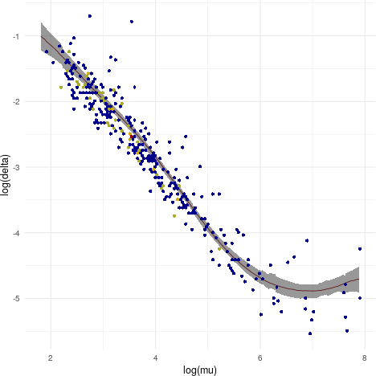

```r
data("ChainRNAReg")
BASiCS_showFit(ChainRNAReg)
```

The `BASiCS_TestDE` test function will automatically perform differential variability testing based on the residual over-dispersion parameters $\epsilon_i$ when its output includes two `Chain` objects that were generated by the regression BASiCS model.

```r
data("ChainSCReg")
Test <- BASiCS_TestDE(Chain1 = ChainSCReg, Chain2 = ChainRNAReg,
                      GroupLabel1 = "SC", GroupLabel2 = "PaS",
                      EpsilonM = log2(1.5), EpsilonD = log2(1.5),
                      EpsilonR = log2(1.5)/log2(exp(1)),
                      EFDR_M = 0.10, EFDR_D = 0.10,
                      Offset = TRUE, PlotOffset = FALSE, Plot = FALSE)
```

This test function outputs an extra slot containing the results of the differential testing residual over-dispersion test. Only genes that are expressed in at least 2 cells (in both groups) are included in the test. Genes that do not satisfy this condition are marked as `ExcludedFromRegression` in the `Test$TableResDisp$ResultDiffResDisp` slot. By performing the regression, all genes can be tested for changes in expression variability independent of changes in mean expression.

```r
head(Test$TableResDisp, n = 2)
```

```
##        GeneName MeanOverall ResDispOverall ResDisp1 ResDisp2 ResDispDistance
## 1 1700094D03Rik      57.353          0.100    0.420   -0.221           0.632
## 2 1700097N02Rik      36.971          0.152    0.438   -0.133           0.432
##   ProbDiffResDisp ResultDiffResDisp
## 1           0.707            NoDiff
## 2           0.613            NoDiff
```

**Note:** Additional parameters for this sampler include: `k` number of regression components (`k`-2 radial basis functions, one intercept and one linear component), `Var` the scale parameter influencing the width of the basis functions and `eta` the degrees of freedom. For additional details about these choices, please refer to Eling et al. (2018).

# 5 Additional details

## 5.1 Storing and loading MCMC chains

To externally store the output of `BASiCS_MCMC` (recommended), additional parameters `StoreChains`, `StoreDir` and `RunName` are required. For example:

```r
Data <- makeExampleBASiCS_Data()
Chain <- BASiCS_MCMC(Data, N = 1000, Thin = 10, Burn = 500, Regression = TRUE,
                     PrintProgress = FALSE, StoreChains = TRUE,
                     StoreDir = tempdir(), RunName = "Example")
```

```
## -----------------------------------------------------
## MCMC sampler has been started: 1000 iterations to go.
## -----------------------------------------------------
## -----------------------------------------------------
## End of Burn-in period.
## -----------------------------------------------------
##
## -----------------------------------------------------
## -----------------------------------------------------
## All 1000 MCMC iterations have been completed.
## -----------------------------------------------------
## -----------------------------------------------------
##
## -----------------------------------------------------
## Please see below a summary of the overall acceptance rates.
## -----------------------------------------------------
##
## Minimum acceptance rate among mu[i]'s: 0.446
## Average acceptance rate among mu[i]'s: 0.6158
## Maximum acceptance rate among mu[i]'s: 0.74
##
##
## Minimum acceptance rate among delta[i]'s: 0.418
## Average acceptance rate among delta[i]'s: 0.51276
## Maximum acceptance rate among delta[i]'s: 0.606
##
##
## Acceptance rate for phi (joint): 0.864
##
##
## Minimum acceptance rate among nu[j]'s: 0.434
## Average acceptance rate among nu[j]'s: 0.532533
## Maximum acceptance rate among nu[j]'s: 0.718
##
##
## Minimum acceptance rate among theta[k]'s: 0.724
## Average acceptance rate among theta[k]'s: 0.724
## Maximum acceptance rate among theta[k]'s: 0.724
##
## -----------------------------------------------------
##
```

In this example, the output of `BASiCS_MCMC` will be stored as a `BASiCS_Chain` object in the file “chain_Example.Rds”, within the `tempdir()` directory.

To load pre-computed MCMC chains,

```r
Chain <- BASiCS_LoadChain("Example", StoreDir = tempdir())
```

## 5.2 Convergence assessment

To assess convergence of the chain, the convergence diagnostics provided by the package `coda` can be used. Additionally, the chains can be visually inspected. For example:

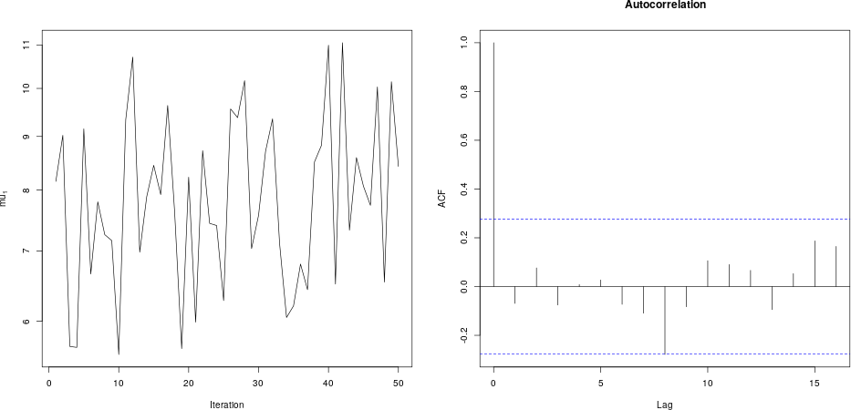

```r
plot(Chain, Param = "mu", Gene = 1, log = "y")
```

See `help(BASiCS_MCMC)` for example plots associated to other model parameters. In the figure above:

- Left panels show traceplots for the chains
- Right panels show the autocorrelation function (see `?acf`)